# Multilevel Modelling Practical 8

## Instructions - start here!

**Exercise 1** involves the analysis of the Betablocker data set used in last week’s lecture. **Exercise 2** digs a little deeper using the same data set. The remaining time can be used to work on the summative assessment.

## Preliminaries

We load the R packages *lme4*, *glmmTMB*, *foreign*, and *ggplot2*.

```r
require(lme4)       # contains glmer
require(glmmTMB)    # alternative package for generalized linear mixed models
```

```r
require(foreign)    # used to read in .csv files
require(ggplot2)    # for the use of ggplot
```

## Exercise 1: Betablocker data

We will initially reproduce the analysis as demonstrated in the lecture. We read the betablocker data directly from the internet.

```r
betablok <- read.table(
  'https://andygolightly.github.io/teaching/MATH43515/betablok.dat')
betablok
```

| V1 | V2 |
| --- | --- |
| 3 | 39 |
| 3 | 38 |
| 14 | 116 |
| 7 | 114 |
| 11 | 93 |
| 5 | 69 |
| 127 | 1520 |
| 102 | 1533 |
| 27 | 365 |
| 28 | 355 |

[output cut: 34 more lines]

Add trial and centre information:

```r
names(betablok) <- c('r','n')
betablok$treat <- factor(gl(2,1),labels=c(0,1))
betablok$center <- gl(22,2)
```

Quick glance at data layout:

```r
dim(betablok)
```

```
## [1] 44  4
```

```r
head(betablok)
```

|  | r | n | treat | center |
| --- | --- | --- | --- | --- |
| 1 | 3 | 39 | 0 | 1 |
| 2 | 3 | 38 | 1 | 1 |
| 3 | 14 | 116 | 0 | 2 |
| 4 | 7 | 114 | 1 | 2 |
| 5 | 11 | 93 | 0 | 3 |
| 6 | 5 | 69 | 1 | 3 |

GLM fit ignoring multi-level structure:

```r
betablok.glm <- glm(cbind(r,(n-r))~treat,data=betablok,family=binomial)
summary(betablok.glm)
```

```
##
## Call:
## glm(formula = cbind(r, (n - r)) ~ treat, family = binomial, data = betablok)
##
## Deviance Residuals:
##     Min       1Q   Median       3Q      Max
## -5.3160  -1.4916  -0.1341   1.7067   5.8564
##
## Coefficients:
##             Estimate Std. Error z value Pr(>|z|)
## (Intercept) -2.19711    0.03359 -65.417  < 2e-16 ***
## treat1      -0.25737    0.04942  -5.207 1.91e-07 ***
## ---
## Signif. codes:  0 '***' 0.001 '**' 0.01 '*' 0.05 '.' 0.1 ' ' 1
##
## (Dispersion parameter for binomial family taken to be 1)
##
##     Null deviance: 332.99  on 43  degrees of freedom
## Residual deviance: 305.76  on 42  degrees of freedom
## AIC: 527.19
##
## Number of Fisher Scoring iterations: 4
```

Note the AIC value of 527. Recall that AIC is given by $2k-2\log\hat{L}$ where $\log\hat{L}$ is the maximised log-likelihood. When comparing two (potentially non-nested) models, we prefer the model with smaller AIC.

Now accounting for two-level structure, with `center` (i.e. hospital) in the upper level:

```r
summary(betablok.glmer <- glmer(cbind(r,(n-r))~treat+(1|center), data=betablok, family=binomial))
```

```
## Generalized linear mixed model fit by maximum likelihood (Laplace
##   Approximation) [glmerMod]
##  Family: binomial  ( logit )
## Formula: cbind(r, (n - r)) ~ treat + (1 | center)
##    Data: betablok
##
##      AIC      BIC   logLik deviance df.resid
##    324.4    329.8   -159.2    318.4       41
##
## Scaled residuals:
##     Min      1Q  Median      3Q     Max
## -1.8876 -0.5129  0.0605  0.4969  1.8623
##
## Random effects:
##  Groups Name        Variance Std.Dev.
##  center (Intercept) 0.2362   0.486
## Number of obs: 44, groups:  center, 22
##
## Fixed effects:
##             Estimate Std. Error z value Pr(>|z|)
## (Intercept) -2.19618    0.11292 -19.450  < 2e-16 ***
## treat1      -0.26091    0.04982  -5.237 1.63e-07 ***
## ---
## Signif. codes:  0 '***' 0.001 '**' 0.01 '*' 0.05 '.' 0.1 ' ' 1
##
## Correlation of Fixed Effects:
##        (Intr)
## treat1 -0.205
```

Note the AIC value of 324. Now, let’s think about the treatment effect. We have the following model:
$$Y_{ij} \sim Binomial(n_{ij},\pi_{ij})$$
for treatment $i$ in center $j$. Note that $\pi_{ij}$ is the probability of patient mortality for that treatment-center combination. We further have via the *logit* link that
$$\log\left(\frac{\pi_{ij}}{1-\pi_{ij}}\right)=a+u_j+b x_{ij}$$
which gives
$$\pi_{ij}= \frac{e^{a+u_j+b x_{ij}}}{1+e^{a+u_j+b x_{ij}}}$$
where $x_{ij}$ is 0 or 1 for no treatment versus treatment and $u_j\sim N(0,\sigma^2_u)$ is the random intercept term. When $x_{ij}=0$ the expected log-odds ratio is
$$\hat{a}=-2.2.$$
When $x_{ij}=1$, the expected log-odds ratio is
$$\hat{a}+\hat{b} = -2.2 - 0.26.$$
Hence, the effect of treatment is the change the log-odds ratio by -0.26 and therefore multiply the odds-ratio (in favour of death) by $exp(-0.26)=0.77$. That is, the treatment *appears to be effective in reducing probability of patient mortality*.

This observation has also been made in the literature; e.g. Aitkin et al (2009, Statistical Modelling in R, page 526), note: “The treatment produces a significant, though small, reduction in death risk compared to the control: the odds of death are reduced…”.

We can do a little diagnostc checking by looking at the normality assumption for the random intercept terms:

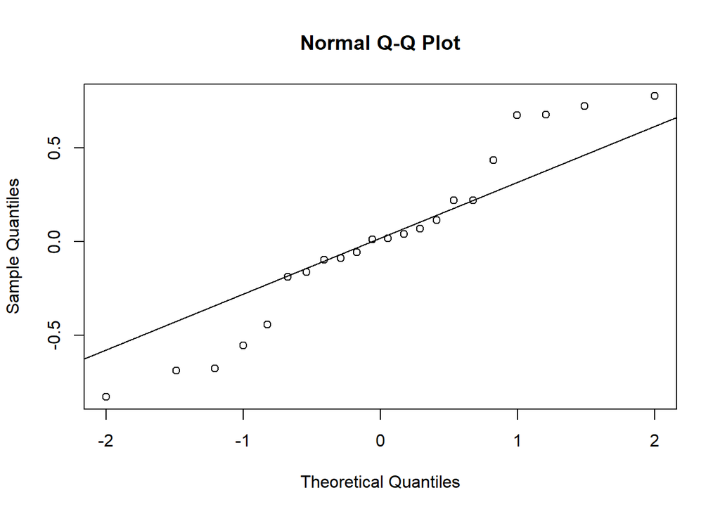

```r
qqnorm(ranef(betablok.glmer)$center[,1])
qqline(ranef(betablok.glmer)$center[,1])
```

which doesn’t look too bad given the size of the data set.

## Exercise 2 (digging deeper)

This is a multi-centre trial, so (in terms of analysis) comparable to a multi-site trial. Hence, a natural extension of the preceding analysis would be the consideration of random slopes. Adapt model `betablok.glmer` accordingly so that it allows for centre-specific slopes.

```r
summary(betablok.glmer2 <- glmer(cbind(r,(n-r))~treat+(treat|center),data=betablok,
                      family=binomial))
```

```
## Generalized linear mixed model fit by maximum likelihood (Laplace
##   Approximation) [glmerMod]
##  Family: binomial  ( logit )
## Formula: cbind(r, (n - r)) ~ treat + (treat | center)
##    Data: betablok
##
##      AIC      BIC   logLik deviance df.resid
##    327.7    336.6   -158.8    317.7       39
##
## Scaled residuals:
##      Min       1Q   Median       3Q      Max
## -1.45612 -0.40887  0.02525  0.44137  1.39542
##
## Random effects:
##  Groups Name        Variance Std.Dev. Corr
##  center (Intercept) 0.254613 0.5046
##         treat1      0.009585 0.0979   -0.45
## Number of obs: 44, groups:  center, 22
##
## Fixed effects:
##             Estimate Std. Error z value Pr(>|z|)
## (Intercept) -2.20413    0.11749 -18.760  < 2e-16 ***
## treat1      -0.24681    0.05888  -4.192 2.77e-05 ***
## ---
## Signif. codes:  0 '***' 0.001 '**' 0.01 '*' 0.05 '.' 0.1 ' ' 1
##
## Correlation of Fixed Effects:
##        (Intr)
## treat1 -0.364
```

Consider AIC and the log-likelihood. Do the random slopes appear to be worth including?

Apply function `anova` on the pair of models to endorse your judgement.

```r
anova(betablok.glmer, betablok.glmer2)
```

|  | npar | AIC | BIC | logLik | deviance | Chisq | Df | Pr(>Chisq) |
| --- | --- | --- | --- | --- | --- | --- | --- | --- |
| betablok.glmer | 3 | 324.4206 | 329.7732 | -159.2103 | 318.4206 | NA | NA | NA |
| betablok.glmer2 | 5 | 327.6545 | 336.5755 | -158.8273 | 317.6545 | 0.7660661 | 2 | 0.6817904 |

What does the random slope model tell us now about the intervention effect?

Carry out residual diagnostics on both models (using `plot(..)`).

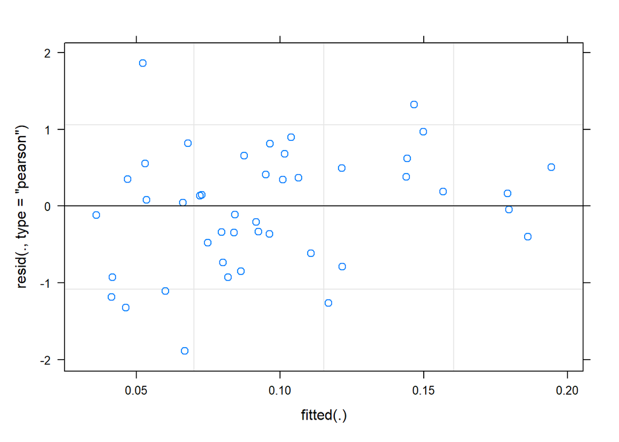

```r
plot(betablok.glmer)
```

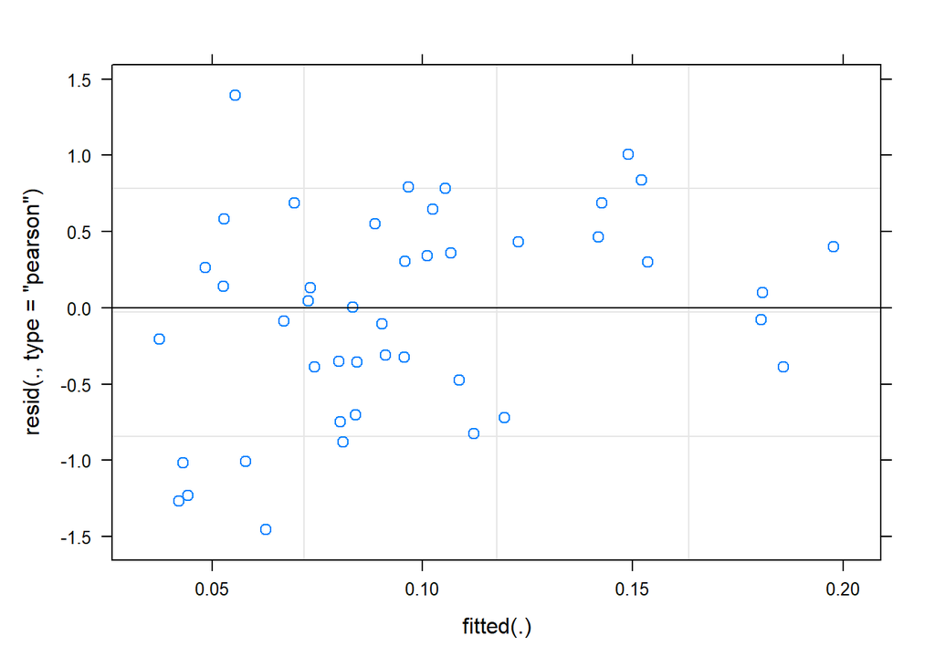

```r
plot(betablok.glmer2)
```

Also inspect the random effects (using `plot_model`).

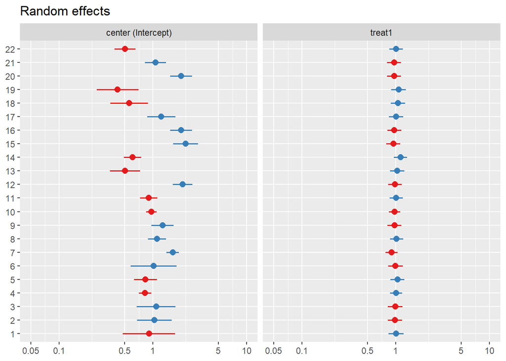

```r
require(sjPlot)
plot_model(betablok.glmer2, type="re")
```

What is your overall conclusion?

## Summative assessment

If there is still time remaining, please use this to work on your summative assessment.